# MIS 665: Final Project

### By Nicole Becker

### Monday, Dec. 9, 2019

**K-State Honor Code:** On my honor, as a student, I have neither given nor received unauthorized aid on this academic work.  
*Nicole Becker*

```python
from IPython.display import Image
from IPython.core.display import HTML
Image(url= "https://media.dragonblogger.com/wp-content/uploads/2018/01/03135447/img_5a4d51253ca98.jpg",width=600,height=600)
```

[figure not shown]

# Part I: Data Cleaning and Descriptive Analysis

## 1. Introduction

In this project, I seek to evaluate the historic success of movies and determine which factors have the highest impact on such success. Success in this industry can be quite subjective, as it involves the opinion of others. However, with numerous factors, we can determine trends in movies that end up "successful" and those with worse ratings. For this project, success is related to a high IMDB sccore for the movie. Through this project, I will determine some of the largest predictors of high IMDB scores and high profits for a movie.

### 1.a. Background Information

*Research Summary*

IMDB began in the 1990s, and it was created to collect information about movies and television series and assemble the information into a database. Now, it contains thousands of entries regarding movies and television, and people can rate each movie, which is aggregated into an IMDB Score. This score indicates how well-liked a movie is by the general public.

### 1.b. Business Objective

*Project Goals*

In this project, I will predict the historic success of movies based on the IMDB score and profits. With this, I will determine what type of characteristics are likely to lead to a successful movie.

This is important because it assists movie makers in creating more favorable movies. This would lead to more profits for movie makers, and perhaps, more profits for the movie industry as a whole. Likewise, the general population would gain more entertainment benefits from movies moving forward.

```python
df.groupby('content_rating').size()
```

```
content_rating
1         112
2         709
3        1444
4        2338
5          20
TV-14      30
TV-G       10
TV-MA      19
TV-PG      13
TV-Y        1
TV-Y7       1
dtype: int64
```

I will create a new variable called 'profit,' that will subtract the movie budget from it's gross revenue. This column is relevant because ultimately, this depicts how much money the company made from the movie. This is what should drive a lot of the movie producers to success.

```python
px.histogram(df, x='title_year', y='profit', histfunc='avg', labels={'title_year':'Year of Release', 'profit' : 'Profit'})
```

[interactive chart not shown]

# Part II: Machine Learning and Predictive Analysis

## 1. Regression

In this section, I will seek to predict IMDB score based on the important factors. Based on my previous analyis, I expect the following variables to impact the regression model:

1. Number of Users Who Voted
2. Movie Duration
3. Number of Movie Facebook Likes
4. Movie Content Rating
5. Number of Critics Who Reviewed

**Regression with all variables**

```python
# build a multiple regression model

model = lm.LinearRegression()
model.fit(X, y)
model_y = model.predict(X)
```

```python
#display coefficients with each variable
pd.DataFrame(list(zip(X.columns, np.transpose(model.coef_))))
```

|  | 0 | 1 |
| --- | --- | --- |
| 0 | color | -0.370631 |
| 1 | num_critic_for_reviews | 0.002267 |
| 2 | duration | 0.009631 |
| 3 | director_facebook_likes | 0.000007 |
| 4 | actor_3_facebook_likes | 0.000061 |
| 5 | actor_1_facebook_likes | 0.000064 |
| 6 | gross | -22203.147149 |
| 7 | num_voted_users | 0.000004 |
| 8 | cast_total_facebook_likes | 0.018865 |
| 9 | facenumber_in_poster | -0.023281 |
| 10 | num_user_for_reviews | -0.000668 |
| 11 | country | -0.327182 |
| 12 | content_rating | 0.084784 |
| 13 | budget | 22203.147149 |
| 14 | title_year | -0.019507 |
| 15 | actor_2_facebook_likes | 0.000065 |
| 16 | aspect_ratio | -0.066634 |
| 17 | movie_facebook_likes | 0.018925 |
| 18 | profit | 22203.147149 |
| 19 | facebook_total | -0.018927 |

```python
#check accuracy
print("mean square error: ", mean_squared_error(y, model_y))
print("variance or r-squared: ", explained_variance_score(y, model_y))
```

```
mean square error:  0.6869618613488121
variance or r-squared:  0.3810665819197737
```

This model isn't very accurate witha mean square error of 0.69. This could be due to so many different variables playing into the outcome. Also, using this many variables for regression analysis isn't very practic as it's difficult to interpret and apply.

**Regression with Feature Selection**

The important predictors are **number of critics for review, duration, number of users who voted,** and **number of users who reveiewed.**

```python
#model and report error
model2 = lm.LinearRegression()
model2.fit(X_new, y)
model2_y = model2.predict(X_new)

print("mean square error: ", mean_squared_error(y, model2_y))
print("variance or r-squared: ", explained_variance_score(y, model2_y))
```

```
mean square error:  0.7783213546410815
variance or r-squared:  0.2987542075741195
```

```python
print('Coefficients: ', model2.coef_)
print("y-intercept ", model2.intercept_)
```

```
Coefficients:  [ 1.02612301e-03  1.14196167e-02  3.43965678e-06 -5.57066735e-04]
y-intercept  4.861651837174762
```

This model is less accurate with a mean square error of 78%, but it's easier to use in application with less variables to interpret.

**Selecting Best Model**

The regression model created using *feature selection* should be used moving forward because it is easier to interpret. Neither model has a desirable mean square error, but it potentially could be improved upon by collecting more data.

## 2. Classification

In this section, I will create a classification model to predict if each movie is "good" or "bad." To do this, I will classify each score into bins. The bins are as follows:

- IMDB score < 4 is *bad*
- 4 <= IMDB score < 6 is *okay*
- 6 <= IMDB score < 8 is *good*
- 8 <= IMDB score <= 10 is *excecllent*

**Decision Tree**

```python
#create x and y
y6 = df6['imdbscores_bins']
X6 = df6.drop(['imdb_score','imdbscores_bins', 'director_name','actor_1_name','actor_2_name','actor_3_name','genres','movie_title','plot_keywords','movie_imdb_link','language'], axis =1)

print(y6.shape, X6.shape)
```

```
(3777,) (3777, 20)
```

```python
# split validation

X_train6, X_test6, y_train6, y_test6 = train_test_split(X6, y6, test_size=0.3, random_state=42)

# Initialize DecisionTreeClassifier() ... name your decision model "dt"

dt = DecisionTreeClassifier(max_depth=3, min_samples_leaf=5)

# Train a decision tree model

dt = dt.fit(X_train6,y_train6)

dt
```

```
DecisionTreeClassifier(class_weight=None, criterion='gini', max_depth=3,
                       max_features=None, max_leaf_nodes=None,
                       min_impurity_decrease=0.0, min_impurity_split=None,
                       min_samples_leaf=5, min_samples_split=2,
                       min_weight_fraction_leaf=0.0, presort=False,
                       random_state=None, splitter='best')
```

```python
#import decision tree packages
from graphviz import Source
from sklearn import tree
Source( tree.export_graphviz(dt, out_file=None, feature_names=X.columns))
```

[figure not shown]

```python
# Find out the performance of this model & interpret the results

print(metrics.accuracy_score(y_test6, dt.predict(X_test6))) #overall accuracy
print(metrics.confusion_matrix(y_test6, dt.predict(X_test6)))
print(metrics.classification_report(y_test6,dt.predict(X_test6)))
```

```
0.708994708994709
[[  0   0  18  13]
 [  0  19  33   0]
 [  0   7 637  95]
 [  0   0 164 148]]
              precision    recall  f1-score   support

         bad       0.00      0.00      0.00        31
   excellent       0.73      0.37      0.49        52
        good       0.75      0.86      0.80       739
        okay       0.58      0.47      0.52       312

    accuracy                           0.71      1134
   macro avg       0.51      0.43      0.45      1134
weighted avg       0.68      0.71      0.69      1134
```

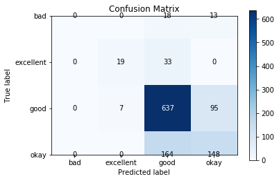

```python
#import confusion matrix package
import scikitplot as skplt

#create confusion matrix
skplt.metrics.plot_confusion_matrix(y_true=np.array(y_test6), y_pred=dt.predict(X_test6))
plt.show()
```

**10 Fold Cross Validation**

```python
# evaluate the decision tree model using 10-fold cross-validation

# initialize decision tree algorithm (without fitting)

scores = cross_val_score(DecisionTreeClassifier(max_depth=3, min_samples_leaf=5), X6, y6, scoring='accuracy', cv=10)
print(scores)
print(scores.mean())
```

```
[0.66226913 0.73350923 0.73087071 0.7176781  0.77044855 0.69496021
 0.67639257 0.68700265 0.65691489 0.656     ]
0.698604605687647
```

```python
# https://scikit-learn.org/stable/modules/cross_validation.html
#The mean score and the 95% confidence interval of the score estimate are hence given by:
print("Accuracy: %0.2f (+/- %0.2f)" % (scores.mean(), scores.std() * 2))
```

```
Accuracy: 0.70 (+/- 0.07)
```

**Random Forest**

```python
#import random forest package
from sklearn.ensemble import RandomForestClassifier

#create random forest model
clf = RandomForestClassifier(n_estimators=20)    #building 20 decision trees
clf=clf.fit(X_train6, y_train6)
clf.score(X_test6, y_test6) #display accuracy
```

```
0.7354497354497355
```

```python
# generate evaluation metrics
print(metrics.accuracy_score(y_test6, clf.predict(X_test6))) #overall accuracy
print(metrics.confusion_matrix(y_test6, clf.predict(X_test6)))
print(metrics.classification_report(y_test6, clf.predict(X_test6)))
```

```
0.7354497354497355
[[  2   0  14  15]
 [  0  26  26   0]
 [  1   5 665  68]
 [  1   0 170 141]]
              precision    recall  f1-score   support

         bad       0.50      0.06      0.11        31
   excellent       0.84      0.50      0.63        52
        good       0.76      0.90      0.82       739
        okay       0.63      0.45      0.53       312

    accuracy                           0.74      1134
   macro avg       0.68      0.48      0.52      1134
weighted avg       0.72      0.74      0.71      1134
```

**KNN**

```python
# Initialize KNeighborClassifier() ... name your decision model "knn"

knn = KNeighborsClassifier()

# Train model

knn = knn.fit(X_train6,y_train6)

knn
```

```
KNeighborsClassifier(algorithm='auto', leaf_size=30, metric='minkowski',
                     metric_params=None, n_jobs=None, n_neighbors=5, p=2,
                     weights='uniform')
```

```python
#Model evaluation
# http://scikit-learn.org/stable/modules/model_evaluation.html
print(metrics.accuracy_score(y_test6, knn.predict(X_test6)))
print("--------------------------------------------------------")
print(metrics.confusion_matrix(y_test6, knn.predict(X_test6)))
print("--------------------------------------------------------")
print(metrics.classification_report(y_test6, knn.predict(X_test6)))
print("--------------------------------------------------------")
```

```
0.5952380952380952
--------------------------------------------------------
[[  0   0  25   6]
 [  0   4  45   3]
 [  4  11 593 131]
 [  0   1 233  78]]
--------------------------------------------------------
              precision    recall  f1-score   support

         bad       0.00      0.00      0.00        31
   excellent       0.25      0.08      0.12        52
        good       0.66      0.80      0.73       739
        okay       0.36      0.25      0.29       312

    accuracy                           0.60      1134
   macro avg       0.32      0.28      0.28      1134
weighted avg       0.54      0.60      0.56      1134

--------------------------------------------------------
```

**KNN with Optimal K**

```python
#create a dictionary of all values we want to test for n_neighbors
params_knn = {'n_neighbors': np.arange(1, 25)}

#use gridsearch to test all values for n_neighbors
knn_gs = GridSearchCV(knn, params_knn, cv=5, iid=False)

#fit model to training data
knn_gs.fit(X_train6, y_train6)
```

```
GridSearchCV(cv=5, error_score='raise-deprecating',
             estimator=KNeighborsClassifier(algorithm='auto', leaf_size=30,
                                            metric='minkowski',
                                            metric_params=None, n_jobs=None,
                                            n_neighbors=5, p=2,
                                            weights='uniform'),
             iid=False, n_jobs=None,
             param_grid={'n_neighbors': array([ 1,  2,  3,  4,  5,  6,  7,  8,  9, 10, 11, 12, 13, 14, 15, 16, 17,
       18, 19, 20, 21, 22, 23, 24])},
             pre_dispatch='2*n_jobs', refit=True, return_train_score=False,
             scoring=None, verbose=0)
```

```python
#save best model
knn_best = knn_gs.best_estimator_

#check best n_neigbors value
print(knn_gs.best_score_)
print(knn_gs.best_params_)
print(knn_gs.best_estimator_)
```

```
0.6594916105863682
{'n_neighbors': 24}
KNeighborsClassifier(algorithm='auto', leaf_size=30, metric='minkowski',
                     metric_params=None, n_jobs=None, n_neighbors=24, p=2,
                     weights='uniform')
```

```python
#create optimal knn
knn = KNeighborsClassifier(n_neighbors=24) #changes number of neighbors to 24 because it's the optimal
knn = knn.fit(X_train6,y_train6) #retrain model for knn of 24
knn
```

```
KNeighborsClassifier(algorithm='auto', leaf_size=30, metric='minkowski',
                     metric_params=None, n_jobs=None, n_neighbors=24, p=2,
                     weights='uniform')
```

**Logistic Regression**

```python
# evaluate the model by splitting into train and test sets and build a logistic regression model
# name it as "lr"

X_train6, X_test6, y_train6, y_test6 = train_test_split(X6, y6, test_size=0.3, random_state=0)
lr = LogisticRegression(solver='lbfgs', max_iter=500)
lr.fit(X_train6, y_train6)
```

```
LogisticRegression(C=1.0, class_weight=None, dual=False, fit_intercept=True,
                   intercept_scaling=1, l1_ratio=None, max_iter=500,
                   multi_class='warn', n_jobs=None, penalty='l2',
                   random_state=None, solver='lbfgs', tol=0.0001, verbose=0,
                   warm_start=False)
```

```python
#Model evaluation

print(metrics.accuracy_score(y_test6, lr.predict(X_test6)))
print(metrics.confusion_matrix(y_test6, lr.predict(X_test6)))
print(metrics.classification_report(y_test6, lr.predict(X_test6)))
#print(metrics.roc_auc_score(y_test6, lr.predict(X_test6)))
```

```
0.6631393298059964
[[  0   0  24   0]
 [  0  22  26   0]
 [  0   4 730   0]
 [  0   0 328   0]]
              precision    recall  f1-score   support

         bad       0.00      0.00      0.00        24
   excellent       0.85      0.46      0.59        48
        good       0.66      0.99      0.79       734
        okay       0.00      0.00      0.00       328

    accuracy                           0.66      1134
   macro avg       0.38      0.36      0.35      1134
weighted avg       0.46      0.66      0.54      1134
```

**Selecting Best Model**

Based on accuracy, the best model is *Random Forest* with 74% accuracy. This model is typically the best in terms of accuracy, but it's not easily inerpretable. Therefore, I recommend we pair the *Deicison Tree* model with a 70.8% accuracy with the Random Forest. The combination of these two will help to paint the full picture and predicting the success of future movies.

## 3. Clustering

In this section, I will create clusters and profile the different clusters to evaluate which movie types are similar with success.

**K-Mean Clustering**

```python
#http://scikit-learn.org/stable/modules/generated/sklearn.cluster.KMeans.html
#four clusters
k_means = KMeans(init='k-means++', n_clusters=4, random_state=0)
```

```python
#normalize data for equal comparison
df7_norm = (df7 - df7.mean()) / (df7.max() - df7.min())
df7_norm.head()
```

|  | color | num_critic_for_reviews | duration | director_facebook_likes | actor_3_facebook_likes | actor_1_facebook_likes | gross | num_voted_users | cast_total_facebook_likes | facenumber_in_poster | ... | content_rating | budget | title_year | actor_2_facebook_likes | imdb_score | aspect_ratio | movie_facebook_likes | profit | facebook_total | imdbscores_bins |
| --- | --- | --- | --- | --- | --- | --- | --- | --- | --- | --- | --- | --- | --- | --- | --- | --- | --- | --- | --- | --- | --- |
| 0 | 0.03283 | 0.687337 | 0.231807 | -0.034736 | 0.004204 | -0.010456 | 0.931698 | 0.462724 | -0.010017 | -0.031982 | ... | -0.070823 | 0.015657 | 0.067196 | -0.007700 | 0.186697 | -0.022535 | 0.068063 | 0.040615 | 0.026152 | 0.095932 |
| 1 | 0.03283 | 0.168225 | 0.201090 | -0.010258 | 0.010508 | 0.050482 | 0.338538 | 0.217131 | 0.056244 | -0.031982 | ... | -0.070823 | 0.020815 | 0.044724 | 0.021964 | 0.082801 | 0.015926 | -0.026493 | 0.000251 | 0.042165 | 0.095932 |
| 2 | 0.03283 | 0.538138 | 0.129418 | -0.034736 | -0.025970 | 0.005169 | 0.194778 | 0.101518 | 0.000437 | -0.008726 | ... | -0.070823 | 0.016312 | 0.134611 | -0.011663 | 0.043840 | 0.015926 | 0.217060 | -0.004014 | 0.115787 | 0.095932 |
| 3 | 0.03283 | 0.798311 | 0.184026 | 0.921786 | 0.967030 | 0.030169 | 0.520951 | 0.615492 | 0.145183 | -0.031982 | ... | -0.070823 | 0.016721 | 0.100903 | 0.153351 | 0.264619 | 0.015926 | 0.443421 | 0.015069 | 0.380826 | 0.429265 |
| 5 | 0.03283 | 0.365512 | 0.074811 | -0.014084 | -0.009926 | -0.011018 | 0.027764 | 0.063841 | -0.014526 | -0.008726 | ... | -0.070823 | 0.017843 | 0.100903 | -0.009919 | 0.017866 | 0.015926 | 0.042275 | -0.015455 | 0.007940 | 0.095932 |

5 rows × 22 columns

```python
#k-means fit model
k_means.fit(df7_norm)
```

```
KMeans(algorithm='auto', copy_x=True, init='k-means++', max_iter=300,
       n_clusters=4, n_init=10, n_jobs=None, precompute_distances='auto',
       random_state=0, tol=0.0001, verbose=0)
```

```python
#To add cluster label into the dataset as a column
df8 = pd.DataFrame(k_means.labels_, columns = ['cluster'])
df8.head()
```

|  | cluster |
| --- | --- |
| 0 | 3 |
| 1 | 3 |
| 2 | 2 |
| 3 | 3 |
| 4 | 3 |

```python
#join cluster results with original data
df7 = df7.reset_index(drop=True)
df8 = df8.reset_index(drop=True)

df9 = df7.join(df8)
df9.head()
```

|  | color | num_critic_for_reviews | duration | director_facebook_likes | actor_3_facebook_likes | actor_1_facebook_likes | gross | num_voted_users | cast_total_facebook_likes | facenumber_in_poster | ... | budget | title_year | actor_2_facebook_likes | imdb_score | aspect_ratio | movie_facebook_likes | profit | facebook_total | imdbscores_bins | cluster |
| --- | --- | --- | --- | --- | --- | --- | --- | --- | --- | --- | --- | --- | --- | --- | --- | --- | --- | --- | --- | --- | --- |
| 0 | 1.0 | 723.0 | 178.0 | 0.0 | 855.0 | 1000.0 | 760505847.0 | 886204 | 4834 | 0.0 | ... | 237000000.0 | 2009.0 | 936.0 | 7.9 | 1.78 | 33000 | 523505847.0 | 37834 | 3 | 3 |
| 1 | 1.0 | 302.0 | 169.0 | 563.0 | 1000.0 | 40000.0 | 309404152.0 | 471220 | 48350 | 0.0 | ... | 300000000.0 | 2007.0 | 5000.0 | 7.1 | 2.35 | 0 | 9404152.0 | 48350 | 3 | 3 |
| 2 | 1.0 | 602.0 | 148.0 | 0.0 | 161.0 | 11000.0 | 200074175.0 | 275868 | 11700 | 1.0 | ... | 245000000.0 | 2015.0 | 393.0 | 6.8 | 2.35 | 85000 | -44925825.0 | 96700 | 3 | 2 |
| 3 | 1.0 | 813.0 | 164.0 | 22000.0 | 23000.0 | 27000.0 | 448130642.0 | 1144337 | 106759 | 0.0 | ... | 250000000.0 | 2012.0 | 23000.0 | 8.5 | 2.35 | 164000 | 198130642.0 | 270759 | 4 | 3 |
| 4 | 1.0 | 462.0 | 132.0 | 475.0 | 530.0 | 640.0 | 73058679.0 | 212204 | 1873 | 1.0 | ... | 263700000.0 | 2012.0 | 632.0 | 6.6 | 2.35 | 24000 | -190641321.0 | 25873 | 3 | 3 |

5 rows × 23 columns

```python
df9.groupby('cluster').mean()
```

| cluster | color | num_critic_for_reviews | duration | director_facebook_likes | actor_3_facebook_likes | actor_1_facebook_likes | gross | num_voted_users | cast_total_facebook_likes | facenumber_in_poster | ... | content_rating | budget | title_year | actor_2_facebook_likes | imdb_score | aspect_ratio | movie_facebook_likes | profit | facebook_total | imdbscores_bins |
| --- | --- | --- | --- | --- | --- | --- | --- | --- | --- | --- | --- | --- | --- | --- | --- | --- | --- | --- | --- | --- | --- |
| 0 | 0.0 | 165.064516 | 116.274194 | 1781.169355 | 545.741935 | 5593.443548 | 3.618791e+07 | 133546.862903 | 8429.653226 | 1.403226 | ... | 3.524194 | 2.750118e+07 | 1994.467742 | 1512.330645 | 7.139516 | 2.012177 | 6490.056452 | 8.686732e+06 | 14919.709677 | 3.064516 |
| 1 | 1.0 | 117.037412 | 100.557128 | 253.378160 | 699.793731 | 6404.816987 | 3.874780e+07 | 41590.415571 | 9708.942366 | 1.559913 | ... | 3.140546 | 3.700533e+07 | 2004.091001 | 1552.832154 | 5.231749 | 2.079616 | 3855.127401 | 1.742471e+06 | 13564.069767 | 1.922144 |
| 2 | 1.0 | 168.122616 | 111.806540 | 342.717984 | 459.486376 | 5484.595368 | 2.913687e+07 | 84978.470027 | 7761.504087 | 1.211172 | ... | 3.378747 | 6.823580e+07 | 2003.377384 | 1252.818801 | 6.719891 | 2.154183 | 8803.046322 | -3.909894e+07 | 16564.550409 | 2.824251 |
| 3 | 1.0 | 189.501036 | 113.906218 | 1188.883420 | 915.596373 | 9325.380311 | 6.839248e+07 | 141964.607772 | 13866.098446 | 1.341195 | ... | 3.304663 | 4.283072e+07 | 2002.883938 | 2526.821244 | 6.951658 | 2.122824 | 12354.268394 | 2.556177e+07 | 26220.366839 | 3.051813 |

4 rows × 22 columns

```python
df9.groupby(['cluster']).count()
#which cluster is the largest
```

| cluster | color | num_critic_for_reviews | duration | director_facebook_likes | actor_3_facebook_likes | actor_1_facebook_likes | gross | num_voted_users | cast_total_facebook_likes | facenumber_in_poster | ... | content_rating | budget | title_year | actor_2_facebook_likes | imdb_score | aspect_ratio | movie_facebook_likes | profit | facebook_total | imdbscores_bins |
| --- | --- | --- | --- | --- | --- | --- | --- | --- | --- | --- | --- | --- | --- | --- | --- | --- | --- | --- | --- | --- | --- |
| 0 | 124 | 124 | 124 | 124 | 124 | 124 | 124 | 124 | 124 | 124 | ... | 124 | 124 | 124 | 124 | 124 | 124 | 124 | 124 | 124 | 124 |
| 1 | 989 | 989 | 989 | 989 | 989 | 989 | 989 | 989 | 989 | 989 | ... | 989 | 989 | 989 | 989 | 989 | 989 | 989 | 989 | 989 | 989 |
| 2 | 734 | 734 | 734 | 734 | 734 | 734 | 734 | 734 | 734 | 734 | ... | 734 | 734 | 734 | 734 | 734 | 734 | 734 | 734 | 734 | 734 |
| 3 | 1930 | 1930 | 1930 | 1930 | 1930 | 1930 | 1930 | 1930 | 1930 | 1930 | ... | 1930 | 1930 | 1930 | 1930 | 1930 | 1930 | 1930 | 1930 | 1930 | 1930 |

4 rows × 22 columns

**K-Mean Clustering with Optimal K**

*The Elbow Method*

The "Elbow" Method is used to determine the optimal k value. This value is at the point where the "elbow" bends. We will evaluate for our current dataset.

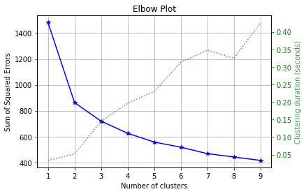

```python
#impoer packages
import scikitplot as skplt

kmeans = KMeans(random_state=1)
skplt.cluster.plot_elbow_curve(kmeans, df7_norm, cluster_ranges=range(1, 10))
```

```python
#3 clusters
k_means2 = KMeans(init='k-means++', n_clusters=3, random_state=0)
```

```python
#k-means fit model
k_means2.fit(df7_norm)
```

```
KMeans(algorithm='auto', copy_x=True, init='k-means++', max_iter=300,
       n_clusters=3, n_init=10, n_jobs=None, precompute_distances='auto',
       random_state=0, tol=0.0001, verbose=0)
```

```python
#To add cluster label into the dataset as a column
df10 = pd.DataFrame(k_means2.labels_, columns = ['cluster'])
df10.head()
```

|  | cluster |
| --- | --- |
| 0 | 1 |
| 1 | 1 |
| 2 | 0 |
| 3 | 1 |
| 4 | 1 |

```python
#join cluster results with original data
df7 = df7.reset_index(drop=True)
df10 = df10.reset_index(drop=True)

df11 = df7.join(df10)
df11.head()
```

|  | color | num_critic_for_reviews | duration | director_facebook_likes | actor_3_facebook_likes | actor_1_facebook_likes | gross | num_voted_users | cast_total_facebook_likes | facenumber_in_poster | ... | budget | title_year | actor_2_facebook_likes | imdb_score | aspect_ratio | movie_facebook_likes | profit | facebook_total | imdbscores_bins | cluster |
| --- | --- | --- | --- | --- | --- | --- | --- | --- | --- | --- | --- | --- | --- | --- | --- | --- | --- | --- | --- | --- | --- |
| 0 | 1.0 | 723.0 | 178.0 | 0.0 | 855.0 | 1000.0 | 760505847.0 | 886204 | 4834 | 0.0 | ... | 237000000.0 | 2009.0 | 936.0 | 7.9 | 1.78 | 33000 | 523505847.0 | 37834 | 3 | 1 |
| 1 | 1.0 | 302.0 | 169.0 | 563.0 | 1000.0 | 40000.0 | 309404152.0 | 471220 | 48350 | 0.0 | ... | 300000000.0 | 2007.0 | 5000.0 | 7.1 | 2.35 | 0 | 9404152.0 | 48350 | 3 | 1 |
| 2 | 1.0 | 602.0 | 148.0 | 0.0 | 161.0 | 11000.0 | 200074175.0 | 275868 | 11700 | 1.0 | ... | 245000000.0 | 2015.0 | 393.0 | 6.8 | 2.35 | 85000 | -44925825.0 | 96700 | 3 | 0 |
| 3 | 1.0 | 813.0 | 164.0 | 22000.0 | 23000.0 | 27000.0 | 448130642.0 | 1144337 | 106759 | 0.0 | ... | 250000000.0 | 2012.0 | 23000.0 | 8.5 | 2.35 | 164000 | 198130642.0 | 270759 | 4 | 1 |
| 4 | 1.0 | 462.0 | 132.0 | 475.0 | 530.0 | 640.0 | 73058679.0 | 212204 | 1873 | 1.0 | ... | 263700000.0 | 2012.0 | 632.0 | 6.6 | 2.35 | 24000 | -190641321.0 | 25873 | 3 | 1 |

5 rows × 23 columns

```python
#evaluate cluster means
df11.groupby('cluster').mean()
```

| cluster | color | num_critic_for_reviews | duration | director_facebook_likes | actor_3_facebook_likes | actor_1_facebook_likes | gross | num_voted_users | cast_total_facebook_likes | facenumber_in_poster | ... | content_rating | budget | title_year | actor_2_facebook_likes | imdb_score | aspect_ratio | movie_facebook_likes | profit | facebook_total | imdbscores_bins |
| --- | --- | --- | --- | --- | --- | --- | --- | --- | --- | --- | --- | --- | --- | --- | --- | --- | --- | --- | --- | --- | --- |
| 0 | 0.952010 | 169.377432 | 112.211414 | 339.088197 | 474.619974 | 5461.856031 | 2.898481e+07 | 86909.110246 | 7775.91310 | 1.217899 | ... | 3.386511 | 6.647515e+07 | 2003.110246 | 1277.147860 | 6.751751 | 2.150454 | 8785.809339 | -3.749034e+07 | 16561.722438 | 2.83917 |
| 1 | 0.962114 | 188.336491 | 113.963111 | 1248.743769 | 898.291127 | 9220.556830 | 6.739756e+07 | 142322.942173 | 13698.25673 | 1.342227 | ... | 3.313061 | 4.212720e+07 | 2002.464606 | 2489.407777 | 6.963410 | 2.117338 | 12129.998504 | 2.527036e+07 | 25828.255234 | 3.05683 |
| 2 | 0.989000 | 116.964000 | 100.649000 | 251.139000 | 696.228000 | 6344.100000 | 3.864602e+07 | 41551.876000 | 9632.00300 | 1.562754 | ... | 3.144000 | 3.699727e+07 | 2004.063000 | 1541.181000 | 5.234400 | 2.079090 | 3816.026000 | 1.648753e+06 | 13448.029000 | 1.92300 |

3 rows × 22 columns

```python
df11.groupby(['cluster']).count()
#which cluster is the largest
```

| cluster | color | num_critic_for_reviews | duration | director_facebook_likes | actor_3_facebook_likes | actor_1_facebook_likes | gross | num_voted_users | cast_total_facebook_likes | facenumber_in_poster | ... | content_rating | budget | title_year | actor_2_facebook_likes | imdb_score | aspect_ratio | movie_facebook_likes | profit | facebook_total | imdbscores_bins |
| --- | --- | --- | --- | --- | --- | --- | --- | --- | --- | --- | --- | --- | --- | --- | --- | --- | --- | --- | --- | --- | --- |
| 0 | 771 | 771 | 771 | 771 | 771 | 771 | 771 | 771 | 771 | 771 | ... | 771 | 771 | 771 | 771 | 771 | 771 | 771 | 771 | 771 | 771 |
| 1 | 2006 | 2006 | 2006 | 2006 | 2006 | 2006 | 2006 | 2006 | 2006 | 2006 | ... | 2006 | 2006 | 2006 | 2006 | 2006 | 2006 | 2006 | 2006 | 2006 | 2006 |
| 2 | 1000 | 1000 | 1000 | 1000 | 1000 | 1000 | 1000 | 1000 | 1000 | 1000 | ... | 1000 | 1000 | 1000 | 1000 | 1000 | 1000 | 1000 | 1000 | 1000 | 1000 |

3 rows × 22 columns

**Hierarchial Clustering**

```python
np.random.seed(1) # setting random seed to get the same results each time.

agg= AgglomerativeClustering(n_clusters=3, linkage='ward').fit(X)
agg.labels_
```

```
array([0, 0, 0, ..., 0, 0, 0], dtype=int64)
```

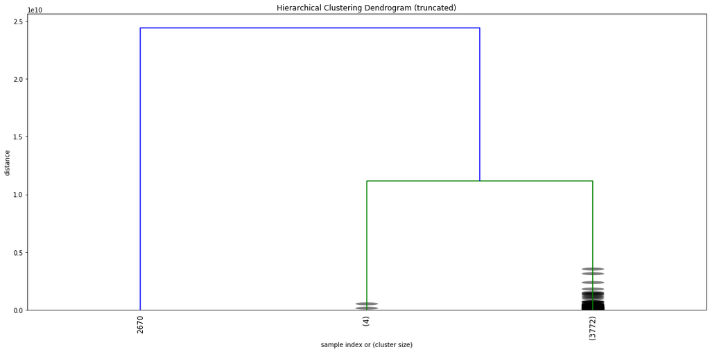

```python
#create hierarchial clustering
plt.figure(figsize=(16,8))

plt.title('Hierarchical Clustering Dendrogram (truncated)')
plt.xlabel('sample index or (cluster size)')
plt.ylabel('distance')

linkage_matrix = ward(X)
dendrogram(linkage_matrix,
           truncate_mode='lastp',  # show only the last p merged clusters
           p=3,  # show only the last p merged clusters
           #show_leaf_counts=False,  # otherwise numbers in brackets are counts
           leaf_rotation=90.,
           leaf_font_size=12.,
           show_contracted=True,  # to get a distribution impression in truncated branches
           orientation="top")
plt.tight_layout() # fixes margins
```

**Clustering Summary**

With the results of placing the data into 3 different clusters, I will create a profile for each cluster.

*Cluster 0*

- IMDB Score Bin: Good movies mixed with okay movies
- Number of Users Voted: Medium
- Dutation: Medium
- Movie Facebook Likes: Medium
- Movie Profit: Negative
- Number Movies in Cluster: 771

*Cluster 1*

- IMDB Score Bin: Good movies
- Number of Users Voted: High
- Duration: Medium
- Movie Facebook Likes: High
- Movie Profit: High
- Number Movies in Cluster: 2,006

From these clusters, the most desired cluster is Cluster 1. This is the movies with the highest average ratings and the average highest profit. While Cluster 0 has the second highest average IMDB rating, it has the lowest average profits at a negative value. This is somewhat concerning, and we should evaluate the priority of having a higher profit or a higher average IMDB score.

## 4. Storytelling

The purpose of this analysis is to identify variables the success of movie, and the company will use this analysis to predict movie success and determine in what areas it's worth investing a movie's budget. In this section, I will summarize my findings for using this data to predict the success of future movies. The client will be able to use this information to take direct action in making more successful movies.

### 4.a. Machine Learning Model Summaries

Throughout this report, I created various machine learning models to analyze past movies and predict the behavior of future movies. In this section, I will detail my findings for each of the three techniques: regression, classification, and clustering.

**Regression Summary**

For regression, I created a model that would predict IMDB score based off all the variables within this dataset. However, after further analysis, I concluded that selecting a few features of the model to understand it better.. Thereore, I used feature selection to create the regression model. The most important variables for this model are:

1. Number of critics who reviewed
2. Duration
3. Number of users who voted
4. Number of users who reviewed

Once I created this model, I found the mean square error to be about 78%.

The Equation for this model is as follows:

IMDB Score = 4.86 + 1.03e-03*(**Number of critics who reviewed**) + 1.14e-02*(**Duration**) + 3.44e-06*(**Number who voted**) - 5.57e-04*(**Number who reviewed**)

With this equation, we wil be able to predict an IMDB score for a movie based on its number of critics who reviewed, duration, number who voted, and number who reviewed. This has implications when looking at new movies to be able to identify success earlier.

**Classification Summary**

For classification, I determined characeteristics for movies within various success categories. The success categories were based on bins of IMDB scores. The bins are as follows:

- IMDB score < 4 is *bad*
- 4 <= IMDB score < 6 is *okay*
- 6 <= IMDB score < 8 is *good*
- 8 <= IMDB score <= 10 is *excecllent*

1. Decision Tree - 71%
2. Random Forest - 74%
3. KNN - 60%
4. Logistic Regression - 66%

From these results, I conclude that Random Forest is the best method in terms of accuracy. However, I also recommend pairing it with Decision tree for easier interpretation.

**Clustering Summary**

From these clusters, the most desired cluster is Cluster 1. This is the movies with the highest average ratings and the average highest profit. While Cluster 0 has the second highest average IMDB rating, it has the lowest average profits at a negative value. This is somewhat concerning, and we should evaluate the priority of having a higher profit or a higher average IMDB score.

### 4.b. Business Applications

**Recommendations for Movie Producers/Investors/Viewers**

The ability to to predict movie success prior to release has huge implications for movie producers. If a movie is projected to perform poorly, the producers could alter aspects to become more like other successful movies, or they could make the decision to scrap the movie before they lose too much money. This would benefit the investors as the companies are able to make better decisions that will result in more promising financial success. Lastly, the viewers would benefit because the industry would consist of more movies that they prefer overall.

**Additional Variables to Improve Model Prediction**

I recommend that we continue to seek out various variables which we could collect to increase the accuracy of our model prediction. As social media is becoming more popular, I recommend the company seeks out ways to track more social media engagement. For example, they could track trailer views, tweets, and other significant metrics. Furthermore, I think it would be interesting to analyze the timing of movie release in correlation to movie success. There are likely to be certain times in the year that people are more likely to go out to see a movie, and it would be interesting to analyze that.

**Moving Forward**

The success of movies is crucial to the movie industry and entertainment overall. Movie success can seem somewhat unpredictable, but with data analytics, we can start to identify trends in successful movies. This analysis should be used by the client to predict how successful movies will be in the future. The ability to predict this has many implications for budgeting, expansions, and risk. Moving forward, I recommend the client continues to evaluate these sort of things and even more. They could expand upon this by generating more variables to evaluate such as movie premier anticipation, movie theater sales, streaming viewers, and more. The movie industry is continually changing, and it's crucial the client stays ahead of this change to remain a key leader within the industry.